# Trial-level analyses

Dani Cosme

2022-11-11

This code reproduces the trial-level analyses reported in the following manuscript:

[Cosme, D., Mobasser, A., & J. H. Pfeifer. If you’re happy and you know it: Neural correlates of self-evaluated psychological health and well-being](https://psyarxiv.com/86n3b/)

# load packages

```r
if(!require('pacman')) {
    install.packages('pacman')
}

pacman::p_load(tidyverse, gtools, GGally, sjstats, lme4, lmerTest, knitr, ggeffects, kableExtra, install = TRUE)
```

# define aesthetics

```r
rois = c("#006989", "#56445D", "#8EC922")
constructs = c("#FEC601", "#F43C13", "#254E70")
instructions = wesanderson::wes_palette("Darjeeling1", 2, "continuous")
valence = c("#119DA4", "#19647E")
plot_aes = theme_minimal() +
  theme(legend.position = "top",
        legend.text = element_text(size = 12),
        text = element_text(size = 16, family = "Futura Medium"),
        axis.text = element_text(color = "black"),
        axis.line = element_line(colour = "black"),
        axis.ticks.y = element_blank(),
        panel.grid.major = element_blank(),
        panel.grid.minor = element_blank(),
        panel.border = element_blank(),
        panel.background = element_blank())
```

# load data

```r
task = read.csv("task_data.csv", stringsAsFactors = FALSE)
betas = read.csv("neuro_data.csv", stringsAsFactors = FALSE)
```

# tidy

- Recode incorrectly named constructs
- Recode negative responses (e.g. no on reversed item = yes) in the social facet

```r
data = task %>%
  extract(subjectID, "subNum", "FP([0-9]{3})", remove = FALSE) %>%
  mutate(construct = ifelse(item == "lonely", "social",
                     ifelse(item == "angry", "ill-being", construct)),
         reversed = ifelse(item == "lonely", 1,
                    ifelse(item == "angry", 0, reversed)),
         instruction = as.factor(instruction),
         construct = as.factor(construct),
         item = as.character(item),
         RT = ifelse(RT == "NaN", NA, RT),
         RT = log(RT) - mean(log(RT), na.rm = TRUE),
         response = ifelse(response == 1, "yes",
                    ifelse(response == 2, "no", NA)),
         responseNum = ifelse(response == "yes" & reversed == 0, 1,
                       ifelse(response == "yes" & reversed == 1, 0,
                       ifelse(response == "no" & reversed == 0, 0,
                       ifelse(response == "no" & reversed == 1, 1, response)))),
         responseNum = as.integer(responseNum),
         responseYN = ifelse(responseNum == 1, "yes",
                      ifelse(responseNum == 0, "no", responseNum)),
         valence = ifelse(construct %in% c("well-being", "social") & reversed == 0, "positive",
                   ifelse(construct %in% c("well-being", "social") & reversed == 1, "negative",
                   ifelse(construct %in% "ill-being" & reversed == 0, "negative",
                   ifelse(construct %in% "ill-being" & reversed == 1, "positive", NA)))),
         valence = as.factor(valence)) %>%
  ungroup() %>%
  mutate(responseYN = as.factor(responseYN))

# relevel factors
data$valence = relevel(data$valence, "positive")
data$construct = relevel(data$construct, "well-being")
```

# exclude outliers and standardize

- Subset self trials
- Exclude outlier trials that are > 3 SDs from roi median across participants

```r
trial_conditions = data %>%
  select(subjectID, trial, run, instruction)

betas_outlier = betas %>%
  left_join(., trial_conditions) %>%
  filter(instruction == "self") %>%
  group_by(roi) %>%
  mutate(median = median(meanPE, na.rm = TRUE),
         sd3 = 3*sd(meanPE, na.rm = TRUE),
         outlier = ifelse(meanPE > median + sd3 | meanPE < median - sd3, "yes", "no"))
betas_outlier %>%
  group_by(outlier) %>%
  summarize(n = n()) %>%
  ungroup() %>%
  mutate(total = sum(n),
         percent = round((n / total) * 100, 2)) %>%
  kable(format = "pandoc")
```

| outlier | n | total | percent |
| --- | --- | --- | --- |
| no | 11900 | 11988 | 99.27 |
| yes | 88 | 11988 | 0.73 |

```r
betas_ex = betas_outlier %>%
  filter(outlier == "no") %>%
  select(-c(median, sd3, outlier))
```

# merge data and exclude participants

- Motion exclusions: FP091
- Technical failure: FP080, FP082
- Non-compliance: FP021, FP049, FP085, FP121
- Standardize within participant and ROI

```r
data_ex = data %>%
  left_join(., betas_ex) %>%
  filter(!subjectID %in% c("FP091", "FP080", "FP082", "FP021", "FP049", "FP085", "FP121")) %>%
  filter(!is.na(meanPE)) %>%
  filter(instruction == "self") %>%
  group_by(roi, subjectID) %>%
  mutate(std = meanPE / sd(meanPE, na.rm = TRUE)) %>%
  select(-sdPE)
```

# remove missing data for MLM analysis

```r
data_complete_mod = data_ex %>%
  select(-meanPE) %>%
  spread(roi, std) %>%
  select(subjectID, trial, run, construct, item, responseYN, RT, pgACC, vmPFC, VS) %>%
  na.omit()
```

# ROI descriptives

```r
# correlations
pgACC_vmPFC = data_complete_mod %>%
   mutate(subjectID = as.factor(subjectID)) %>%
   select(subjectID, pgACC, vmPFC) %>%
   rmcorr::rmcorr(subjectID, pgACC, vmPFC, .)

pgACC_VS = data_complete_mod %>%
   mutate(subjectID = as.factor(subjectID)) %>%
   select(subjectID, pgACC, VS) %>%
   rmcorr::rmcorr(subjectID, pgACC, VS, .)

vmPFC_VS = data_complete_mod %>%
   mutate(subjectID = as.factor(subjectID)) %>%
   select(subjectID, vmPFC, VS) %>%
   rmcorr::rmcorr(subjectID, vmPFC, VS, .)

# means and SDs
mean_table = data_complete_mod %>%
  gather(roi, value, pgACC, vmPFC, VS) %>%
  group_by(roi) %>%
  summarize(M = round(mean(value, na.rm = TRUE), 2),
            SD = round(sd(value, na.rm = TRUE), 2)) %>%
  mutate(order = ifelse(roi == "pgACC", 1,
                 ifelse(roi == "vmPFC", 2, 3)),
         roi = ifelse(roi == "pgACC", "1. pgACC",
               ifelse(roi == "vmPFC", "2. vmPFC", "3. VS"))) %>%
  rename("ROI" = roi) %>%
  arrange(order) %>%
  select(-order)

# table
corr_table = data.frame(ROI = c("1. pgACC", "2. vmPFC", "3. VS"),
           `1` = c("--", paste0(round(pgACC_vmPFC[[1]],2), " [",round(pgACC_vmPFC[[4]][1],2),", ",round(pgACC_vmPFC[[4]][2],2),"]"),
                   paste0(round(pgACC_VS[[1]],2), " [",round(pgACC_VS[[4]][1],2),", ",round(pgACC_VS[[4]][2],2),"]")),
           `2` = c("", "--", paste0(round(vmPFC_VS[[1]],2), " [",round(vmPFC_VS[[4]][1],2),", ",round(vmPFC_VS[[4]][2],2),"]")),
           `3` = c("", "", "--"),
           check.names = FALSE)

mean_table %>%
  full_join(., corr_table) %>%
  knitr::kable(format = "pandoc", caption = "Repeated Measures Correlations Between ROIs (n = 3694). All correlations are statistically significant, p < .001. 95% confidence intervals are bracketed")
```

Repeated Measures Correlations Between ROIs (n = 3694). All correlations are statistically significant, p < .001. 95% confidence intervals are bracketed

| ROI | M | SD | 1 | 2 | 3 |
| --- | --- | --- | --- | --- | --- |
| 1. pgACC | 0.04 | 1.03 | – |  |  |
| 2. vmPFC | 0.15 | 1.02 | 0.84 [0.83, 0.85] | – |  |
| 3. VS | 0.21 | 1.03 | 0.42 [0.39, 0.45] | 0.45 [0.43, 0.48] | – |

# RT models

These are the primary analyses reported in the main text of the manuscript, controlling for reaction time.

## run models

### compare models

Determine the best fitting model.

`model_0_rt` = Base model including including no ROIs

`model_1_rt` = Main effects model including ROIs

`model_2_rt` = Interaction model including ROIs and their interactions with well-being construct

```r
model_0_rt = glmer(responseYN ~ construct * RT +
                     (1 | subjectID),
                family = binomial,
                data = data_complete_mod, control = glmerControl(optimizer = "bobyqa"))

model_1_rt = glmer(responseYN ~ construct * RT + pgACC + vmPFC + VS +
                     (1 | subjectID),
                family = binomial,
                data = data_complete_mod, control = glmerControl(optimizer = "bobyqa"))

model_2_rt = glmer(responseYN ~ RT*construct + pgACC*construct + vmPFC*construct + VS*construct +
                     (1 | subjectID),
                family = binomial,
                data = data_complete_mod, control = glmerControl(optimizer = "bobyqa"))

# compare models
anova(model_0_rt, model_1_rt, model_2_rt)
```

|  | npar | AIC | BIC | logLik | deviance | Chisq | Df | Pr(>Chisq) |
| --- | --- | --- | --- | --- | --- | --- | --- | --- |
| model_0_rt | 7 | 3113.822 | 3157.323 | -1549.911 | 3099.822 | NA | NA | NA |
| model_1_rt | 10 | 3100.486 | 3162.631 | -1540.243 | 3080.486 | 19.33613 | 3 | 0.00023295365 |
| model_2_rt | 16 | 3082.278 | 3181.710 | -1525.139 | 3050.278 | 30.20753 | 6 | 0.00003589336 |

### calculate R2

Compare the model R2 for the best fitting compared to the base model.

```r
performance::r2(model_0_rt)
```

```
## # R2 for Mixed Models
##
##   Conditional R2: 0.512
##      Marginal R2: 0.479
```

```r
performance::r2(model_2_rt)
```

```
## # R2 for Mixed Models
##
##   Conditional R2: 0.532
##      Marginal R2: 0.498
```

### check variance inflation in the best fitting model

```r
# vif
car::vif(model_2_rt)
```

```
##                      GVIF Df GVIF^(1/(2*Df))
## RT               3.986805  1        1.996698
## construct        1.514516  2        1.109350
## pgACC           13.577506  1        3.684767
## vmPFC           13.406848  1        3.661536
## VS               4.932477  1        2.220918
## RT:construct     4.238362  2        1.434827
## construct:pgACC 40.790460  2        2.527200
## construct:vmPFC 48.159436  2        2.634331
## construct:VS     6.643513  2        1.605460
```

## model summary

```r
summary(model_2_rt)
```

```
## Generalized linear mixed model fit by maximum likelihood (Laplace
##   Approximation) [glmerMod]
##  Family: binomial  ( logit )
## Formula: responseYN ~ RT * construct + pgACC * construct + vmPFC * construct +
##     VS * construct + (1 | subjectID)
##    Data: data_complete_mod
## Control: glmerControl(optimizer = "bobyqa")
##
##      AIC      BIC   logLik deviance df.resid
##   3082.3   3181.7  -1525.1   3050.3     3678
##
## Scaled residuals:
##     Min      1Q  Median      3Q     Max
## -8.1633 -0.5202  0.2040  0.3958  3.1031
##
## Random effects:
##  Groups    Name        Variance Std.Dev.
##  subjectID (Intercept) 0.2382   0.488
## Number of obs: 3694, groups:  subjectID, 105
##
## Fixed effects:
##                          Estimate Std. Error z value             Pr(>|z|)
## (Intercept)               1.89473    0.11190  16.933 < 0.0000000000000002 ***
## RT                       -3.15502    0.29983 -10.523 < 0.0000000000000002 ***
## constructill-being       -2.95011    0.12509 -23.584 < 0.0000000000000002 ***
## constructsocial           0.08607    0.14487   0.594             0.552427
## pgACC                     0.44781    0.18873   2.373             0.017655 *
## vmPFC                    -0.39371    0.18838  -2.090             0.036624 *
## VS                        0.10966    0.11201   0.979             0.327546
## RT:constructill-being     3.16001    0.35538   8.892 < 0.0000000000000002 ***
## RT:constructsocial       -0.03286    0.39994  -0.082             0.934513
## constructill-being:pgACC -0.38843    0.22430  -1.732             0.083316 .
## constructsocial:pgACC     0.06794    0.25781   0.264             0.792140
## constructill-being:vmPFC  0.75861    0.22612   3.355             0.000794 ***
## constructsocial:vmPFC    -0.23104    0.26389  -0.875             0.381309
## constructill-being:VS    -0.18072    0.13704  -1.319             0.187253
## constructsocial:VS       -0.03716    0.15560  -0.239             0.811242
## ---
## Signif. codes:  0 '***' 0.001 '**' 0.01 '*' 0.05 '.' 0.1 ' ' 1
```

```
##
## Correlation matrix not shown by default, as p = 15 > 12.
## Use print(x, correlation=TRUE)  or
##     vcov(x)        if you need it
```

## model table

```r
model_2_rt %>%
  broom.mixed::tidy(., conf.int = TRUE) %>%
  filter(effect == "fixed") %>%
  rename("SE" = std.error,
         "z" = statistic,
         "p" = p.value) %>%
  mutate(term = gsub("\\(Intercept\\)", "Intercept (well-being)", term),
         term = gsub("log\\(RT\\)", "RT", term),
         term = gsub("constructill-being", "Construct (ill-being)", term),
         term = gsub("constructsocial", "Construct (social)", term),
         term = gsub(":", " x ", term),
         p = ifelse(p < .001, "< .001",
                    ifelse(p == 1, "1.000", gsub("0.(.*)", ".\\1", sprintf("%.3f", p)))),
         `b [95% CI]` = sprintf("%.2f [%0.2f, %.2f]", estimate, conf.low, conf.high),
         z = abs(round(z, 2))) %>%
  select(term, `b [95% CI]`, z, p) %>%
  kable() %>%
  kableExtra::kable_styling()
```

| term | b [95% CI] | z | p |
| --- | --- | --- | --- |
| Intercept (well-being) | 1.89 [1.68, 2.11] | 16.93 | < .001 |
| RT | -3.16 [-3.74, -2.57] | 10.52 | < .001 |
| Construct (ill-being) | -2.95 [-3.20, -2.70] | 23.58 | < .001 |
| Construct (social) | 0.09 [-0.20, 0.37] | 0.59 | .552 |
| pgACC | 0.45 [0.08, 0.82] | 2.37 | .018 |
| vmPFC | -0.39 [-0.76, -0.02] | 2.09 | .037 |
| VS | 0.11 [-0.11, 0.33] | 0.98 | .328 |
| RT x Construct (ill-being) | 3.16 [2.46, 3.86] | 8.89 | < .001 |
| RT x Construct (social) | -0.03 [-0.82, 0.75] | 0.08 | .935 |
| Construct (ill-being) x pgACC | -0.39 [-0.83, 0.05] | 1.73 | .083 |
| Construct (social) x pgACC | 0.07 [-0.44, 0.57] | 0.26 | .792 |
| Construct (ill-being) x vmPFC | 0.76 [0.32, 1.20] | 3.35 | < .001 |
| Construct (social) x vmPFC | -0.23 [-0.75, 0.29] | 0.88 | .381 |
| Construct (ill-being) x VS | -0.18 [-0.45, 0.09] | 1.32 | .187 |
| Construct (social) x VS | -0.04 [-0.34, 0.27] | 0.24 | .811 |

## marginal probabilities

### all

```r
ggeffect(model_2_rt)
```

```
## $RT
## # Predicted probabilities of responseYN
##
##    RT | Predicted |       95% CI
## --------------------------------
## -1.50 |      0.98 | [0.97, 0.99]
## -1.00 |      0.95 | [0.94, 0.97]
## -0.50 |      0.88 | [0.85, 0.90]
##  0.00 |      0.72 | [0.69, 0.74]
##  0.50 |      0.47 | [0.42, 0.52]
##  1.00 |      0.23 | [0.18, 0.30]
##
## $construct
## # Predicted probabilities of responseYN
##
## construct  | Predicted |       95% CI
## -------------------------------------
## well-being |      0.90 | [0.88, 0.92]
## ill-being  |      0.27 | [0.24, 0.30]
## social     |      0.91 | [0.88, 0.93]
##
## $pgACC
## # Predicted probabilities of responseYN
##
## pgACC | Predicted |       95% CI
## --------------------------------
##    -6 |      0.29 | [0.11, 0.56]
##    -4 |      0.45 | [0.27, 0.64]
##    -2 |      0.62 | [0.52, 0.70]
##     0 |      0.76 | [0.73, 0.79]
##     2 |      0.86 | [0.80, 0.90]
##     4 |      0.93 | [0.85, 0.96]
##     6 |      0.96 | [0.88, 0.99]
##
## $vmPFC
## # Predicted probabilities of responseYN
##
## vmPFC | Predicted |       95% CI
## --------------------------------
##    -4 |      0.89 | [0.77, 0.95]
##    -2 |      0.84 | [0.76, 0.89]
##     0 |      0.77 | [0.74, 0.79]
##     2 |      0.68 | [0.60, 0.76]
##     4 |      0.58 | [0.39, 0.75]
##     6 |      0.47 | [0.22, 0.74]
##
## $VS
## # Predicted probabilities of responseYN
##
## VS | Predicted |       95% CI
## -----------------------------
## -4 |      0.73 | [0.62, 0.82]
## -2 |      0.75 | [0.69, 0.80]
##  0 |      0.76 | [0.73, 0.79]
##  2 |      0.77 | [0.72, 0.82]
##  4 |      0.79 | [0.70, 0.86]
##  6 |      0.80 | [0.66, 0.89]
##
## attr(,"class")
## [1] "ggalleffects" "list"
## attr(,"model.name")
## [1] "model_2_rt"
```

### PCC

```r
ggeffect(model_2_rt, terms = c("construct", "pgACC [0, 1]")) %>%
  data.frame() %>%
  mutate(`b [95% CI]` = sprintf("%.2f [%0.2f, %.2f]", predicted, conf.low, conf.high)) %>%
  kable() %>%
  kableExtra::kable_styling()
```

| x | predicted | std.error | conf.low | conf.high | group | b [95% CI] |
| --- | --- | --- | --- | --- | --- | --- |
| well-being | 0.9013344 | 0.1186400 | 0.8786395 | 0.9201708 | 0 | 0.90 [0.88, 0.92] |
| ill-being | 0.2655697 | 0.0838977 | 0.2347549 | 0.2988497 | 0 | 0.27 [0.23, 0.30] |
| social | 0.9055448 | 0.1222826 | 0.8829576 | 0.9241475 | 0 | 0.91 [0.88, 0.92] |
| well-being | 0.9346218 | 0.2305951 | 0.9009652 | 0.9573814 | 1 | 0.93 [0.90, 0.96] |
| ill-being | 0.2773119 | 0.1447924 | 0.2241536 | 0.3375912 | 1 | 0.28 [0.22, 0.34] |
| social | 0.9413743 | 0.2312485 | 0.9107582 | 0.9619260 | 1 | 0.94 [0.91, 0.96] |

### vmPFC

```r
ggeffect(model_2_rt, terms = c("construct", "vmPFC [0, 1]")) %>%
  data.frame() %>%
  mutate(`b [95% CI]` = sprintf("%.2f [%0.2f, %.2f]", predicted, conf.low, conf.high)) %>%
  kable() %>%
  kableExtra::kable_styling()
```

| x | predicted | std.error | conf.low | conf.high | group | b [95% CI] |
| --- | --- | --- | --- | --- | --- | --- |
| well-being | 0.9078065 | 0.1250074 | 0.8851501 | 0.9263652 | 0 | 0.91 [0.89, 0.93] |
| ill-being | 0.2557263 | 0.0861420 | 0.2249349 | 0.2891603 | 0 | 0.26 [0.22, 0.29] |
| social | 0.9146558 | 0.1344701 | 0.8917072 | 0.9331062 | 0 | 0.91 [0.89, 0.93] |
| well-being | 0.8691461 | 0.1913405 | 0.8203041 | 0.9062302 | 1 | 0.87 [0.82, 0.91] |
| ill-being | 0.3310589 | 0.1367632 | 0.2745915 | 0.3928498 | 1 | 0.33 [0.27, 0.39] |
| social | 0.8515877 | 0.1704146 | 0.8042548 | 0.8890541 | 1 | 0.85 [0.80, 0.89] |

### VS

```r
ggeffect(model_2_rt, terms = c("construct", "VS [0, 1]")) %>%
  data.frame() %>%
  mutate(`b [95% CI]` = sprintf("%.2f [%0.2f, %.2f]", predicted, conf.low, conf.high)) %>%
  kable() %>%
  kableExtra::kable_styling()
```

| x | predicted | std.error | conf.low | conf.high | group | b [95% CI] |
| --- | --- | --- | --- | --- | --- | --- |
| well-being | 0.9008683 | 0.1201384 | 0.8777660 | 0.9200022 | 0 | 0.90 [0.88, 0.92] |
| ill-being | 0.2688923 | 0.0857900 | 0.2371452 | 0.3032003 | 0 | 0.27 [0.24, 0.30] |
| social | 0.9059781 | 0.1228292 | 0.8833710 | 0.9245773 | 0 | 0.91 [0.88, 0.92] |
| well-being | 0.9102402 | 0.1535307 | 0.8824311 | 0.9319785 | 1 | 0.91 [0.88, 0.93] |
| ill-being | 0.2551545 | 0.1038268 | 0.2184359 | 0.2957100 | 1 | 0.26 [0.22, 0.30] |
| social | 0.9119748 | 0.1598484 | 0.8833653 | 0.9340902 | 1 | 0.91 [0.88, 0.93] |

## plot predicted effects

### by construct

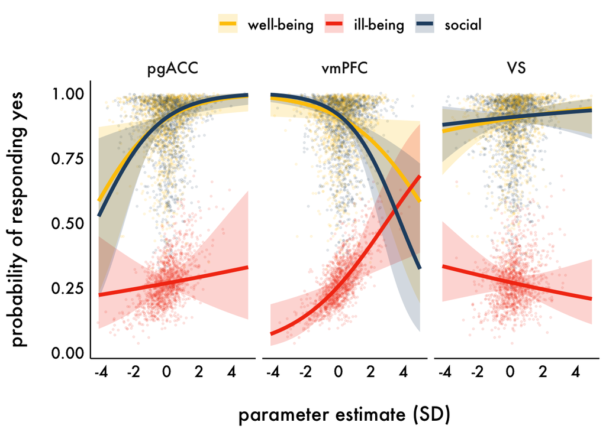

```r
logit2prob = function(logit){
  odds <- exp(logit)
  prob <- odds / (1 + odds)
  return(prob)
}

raw_values = data_complete_mod %>%
  select(subjectID, construct, RT, pgACC, vmPFC, VS)

raw_values$predicted_logit = predict(model_2_rt, newdata = raw_values, re.form = as.formula("~(1 | subjectID)"))

raw_values = raw_values %>%
  gather(roi, x, pgACC, VS, vmPFC) %>%
  rename("group" = construct) %>%
  mutate(predicted = logit2prob(predicted_logit))

vals = seq(round(min(raw_values$x),1), round(max(raw_values$x), 1), .2)

predicted = ggeffect(model_2_rt, terms = c("pgACC [vals]", "construct")) %>%
  data.frame() %>%
  mutate(roi = "pgACC") %>%
  bind_rows(ggeffect(model_2_rt, terms = c("VS [vals]", "construct")) %>%
    data.frame() %>%
    mutate(roi = "VS")) %>%
  bind_rows(ggeffect(model_2_rt, terms = c("vmPFC [vals]", "construct")) %>%
    data.frame() %>%
    mutate(roi = "vmPFC"))

predicted %>%
  ggplot(aes(x, predicted, fill = group)) +
  geom_point(data = raw_values, aes(color = group), alpha = .1, size = .5) +
  geom_ribbon(aes(ymin = conf.low, ymax = conf.high), alpha = .2) +
  geom_line(aes(color = group), size = 1.5) +
  facet_grid(~roi) +
  scale_color_manual(values = constructs, name = "") +
  scale_fill_manual(values = constructs, name = "") +
  scale_x_continuous(breaks = seq(-6, 6, 2)) +
  labs(x = "\nparameter estimate (SD)", y = "probability of responding yes\n") +
  plot_aes
```

### by ROI

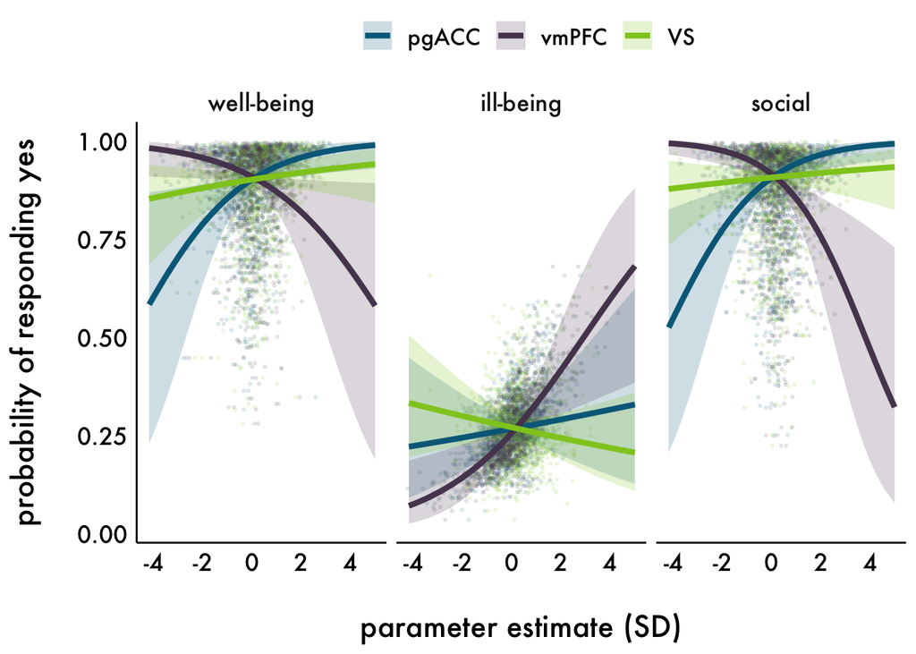

```r
predicted %>%
  ggplot(aes(x, predicted, fill = roi)) +
  geom_point(data = raw_values, aes(color = roi), alpha = .1, size = .5) +
  geom_ribbon(aes(ymin = conf.low, ymax = conf.high), alpha = .2) +
  geom_line(aes(color = roi), size = 1.5) +
  facet_grid(~group) +
  scale_color_manual(values = rois, name = "") +
  scale_fill_manual(values = rois, name = "") +
  scale_x_continuous(breaks = seq(-6, 6, 2)) +
  labs(x = "\nparameter estimate (SD)", y = "probability of responding yes\n") +
  plot_aes
```

### RT

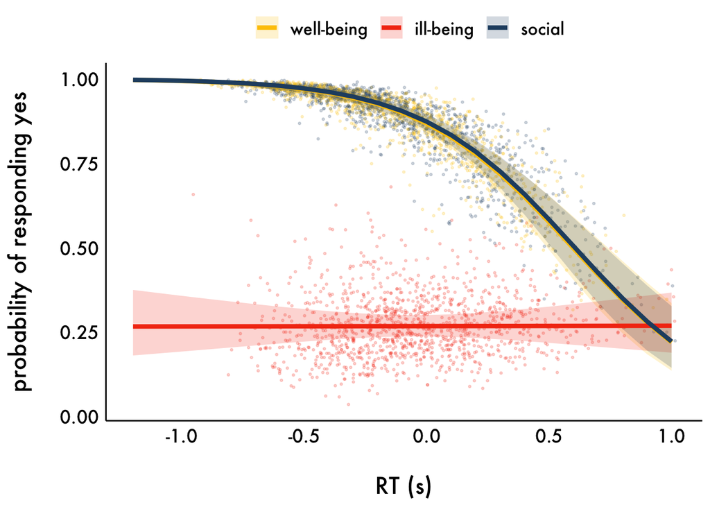

```r
raw_values = data_complete_mod %>%
  select(subjectID, construct, RT, pgACC, vmPFC, VS)

raw_values$predicted_logit = predict(model_2_rt, newdata = raw_values, re.form = as.formula("~(1 | subjectID)"))

raw_values = raw_values %>%
  rename("group" = construct,
         "x" = RT) %>%
  mutate(predicted = logit2prob(predicted_logit))

vals = seq(round(min(raw_values$x),1), round(max(raw_values$x), 1), .1)

ggeffect(model_2_rt, terms = c("RT [vals]", "construct")) %>%
  data.frame() %>%
  ggplot(aes(x, predicted, fill = group, group = group)) +
  geom_point(data = raw_values, aes(color = group), alpha = .2, size = .5) +
  geom_ribbon(aes(ymin = conf.low, ymax = conf.high), alpha = .2) +
  geom_line(aes(color = group), size = 1.5) +
  scale_color_manual(values = constructs, name = "") +
  scale_fill_manual(values = constructs, name = "") +
  labs(x = "\nRT (s)", y = "probability of responding yes\n") +
  plot_aes
```

# no RT model

These are the original preregistered analyses not controlling for reaction time, reported in supplementary material.

## run model

```r
model_2 = glmer(responseYN ~ construct + pgACC*construct + vmPFC*construct + VS*construct +
                     (1 | subjectID),
                family = binomial,
                data = data_complete_mod, control = glmerControl(optimizer = "bobyqa"))
```

## model summary

```r
summary(model_2)
```

```
## Generalized linear mixed model fit by maximum likelihood (Laplace
##   Approximation) [glmerMod]
##  Family: binomial  ( logit )
## Formula: responseYN ~ construct + pgACC * construct + vmPFC * construct +
##     VS * construct + (1 | subjectID)
##    Data: data_complete_mod
## Control: glmerControl(optimizer = "bobyqa")
##
##      AIC      BIC   logLik deviance df.resid
##   3355.6   3436.4  -1664.8   3329.6     3681
##
## Scaled residuals:
##     Min      1Q  Median      3Q     Max
## -3.6442 -0.5280  0.3366  0.4098  3.0378
##
## Random effects:
##  Groups    Name        Variance Std.Dev.
##  subjectID (Intercept) 0.1913   0.4373
## Number of obs: 3694, groups:  subjectID, 105
##
## Fixed effects:
##                          Estimate Std. Error z value             Pr(>|z|)
## (Intercept)               2.01006    0.10105  19.892 < 0.0000000000000002 ***
## constructill-being       -3.05942    0.11701 -26.146 < 0.0000000000000002 ***
## constructsocial          -0.09374    0.12688  -0.739              0.46005
## pgACC                     0.24530    0.15335   1.600              0.10969
## vmPFC                    -0.22700    0.15459  -1.468              0.14200
## VS                        0.12710    0.09062   1.403              0.16072
## constructill-being:pgACC -0.19387    0.19552  -0.992              0.32140
## constructsocial:pgACC     0.01747    0.21060   0.083              0.93390
## constructill-being:vmPFC  0.59383    0.19902   2.984              0.00285 **
## constructsocial:vmPFC    -0.07918    0.21654  -0.366              0.71460
## constructill-being:VS    -0.19412    0.12025  -1.614              0.10646
## constructsocial:VS       -0.07810    0.12521  -0.624              0.53281
## ---
## Signif. codes:  0 '***' 0.001 '**' 0.01 '*' 0.05 '.' 0.1 ' ' 1
##
## Correlation of Fixed Effects:
##             (Intr) cnstr- cnstrc pgACC  vmPFC  VS     c-:ACC cn:ACC c-:PFC
## cnstrctll-b -0.725
## constrctscl -0.627  0.543
## pgACC        0.210 -0.182 -0.164
## vmPFC       -0.179  0.155  0.139 -0.804
## VS          -0.079  0.068  0.060 -0.087 -0.197
## cnstrc-:ACC -0.161  0.184  0.129 -0.773  0.621  0.067
## cnstrct:ACC -0.156  0.137  0.261 -0.718  0.577  0.062  0.562
## cnstrc-:PFC  0.142 -0.188 -0.109  0.615 -0.766  0.151 -0.793 -0.448
## cnstrct:PFC  0.128 -0.112 -0.286  0.566 -0.703  0.139 -0.443 -0.799  0.546
## cnstrct-:VS  0.058 -0.128 -0.044  0.066  0.145 -0.745 -0.078 -0.048 -0.208
## cnstrcts:VS  0.053 -0.046 -0.057  0.060  0.140 -0.712 -0.049 -0.075 -0.109
##             cn:PFC cn-:VS
## cnstrctll-b
## constrctscl
## pgACC
## vmPFC
## VS
## cnstrc-:ACC
## cnstrct:ACC
## cnstrc-:PFC
## cnstrct:PFC
## cnstrct-:VS -0.104
## cnstrcts:VS -0.215  0.537
```

## model table

```r
model_2 %>%
  broom.mixed::tidy(., conf.int = TRUE) %>%
  filter(effect == "fixed") %>%
  rename("SE" = std.error,
         "z" = statistic,
         "p" = p.value) %>%
  mutate(term = gsub("\\(Intercept\\)", "Intercept (well-being)", term),
         term = gsub("log\\(RT\\)", "RT", term),
         term = gsub("constructill-being", "Construct (ill-being)", term),
         term = gsub("constructsocial", "Construct (social)", term),
         term = gsub(":", " x ", term),
         p = ifelse(p < .001, "< .001",
                    ifelse(p == 1, "1.000", gsub("0.(.*)", ".\\1", sprintf("%.3f", p)))),
         `b [95% CI]` = sprintf("%.2f [%0.2f, %.2f]", estimate, conf.low, conf.high),
         z = abs(round(z, 2))) %>%
  select(term, `b [95% CI]`, z, p) %>%
  kable() %>%
  kableExtra::kable_styling()
```

| term | b [95% CI] | z | p |
| --- | --- | --- | --- |
| Intercept (well-being) | 2.01 [1.81, 2.21] | 19.89 | < .001 |
| Construct (ill-being) | -3.06 [-3.29, -2.83] | 26.15 | < .001 |
| Construct (social) | -0.09 [-0.34, 0.15] | 0.74 | .460 |
| pgACC | 0.25 [-0.06, 0.55] | 1.60 | .110 |
| vmPFC | -0.23 [-0.53, 0.08] | 1.47 | .142 |
| VS | 0.13 [-0.05, 0.30] | 1.40 | .161 |
| Construct (ill-being) x pgACC | -0.19 [-0.58, 0.19] | 0.99 | .321 |
| Construct (social) x pgACC | 0.02 [-0.40, 0.43] | 0.08 | .934 |
| Construct (ill-being) x vmPFC | 0.59 [0.20, 0.98] | 2.98 | .003 |
| Construct (social) x vmPFC | -0.08 [-0.50, 0.35] | 0.37 | .715 |
| Construct (ill-being) x VS | -0.19 [-0.43, 0.04] | 1.61 | .106 |
| Construct (social) x VS | -0.08 [-0.32, 0.17] | 0.62 | .533 |

## marginal probabilities

### all

```r
ggeffect(model_2)
```

```
## $construct
## # Predicted probabilities of responseYN
##
## construct  | Predicted |       95% CI
## -------------------------------------
## well-being |      0.88 | [0.86, 0.90]
## ill-being  |      0.27 | [0.24, 0.30]
## social     |      0.87 | [0.85, 0.89]
##
## $pgACC
## # Predicted probabilities of responseYN
##
## pgACC | Predicted |       95% CI
## --------------------------------
##    -6 |      0.46 | [0.24, 0.70]
##    -4 |      0.55 | [0.39, 0.71]
##    -2 |      0.64 | [0.56, 0.72]
##     0 |      0.72 | [0.70, 0.75]
##     2 |      0.79 | [0.73, 0.84]
##     4 |      0.85 | [0.74, 0.91]
##     6 |      0.89 | [0.75, 0.96]
##
## $vmPFC
## # Predicted probabilities of responseYN
##
## vmPFC | Predicted |       95% CI
## --------------------------------
##    -4 |      0.77 | [0.62, 0.87]
##    -2 |      0.75 | [0.67, 0.81]
##     0 |      0.73 | [0.70, 0.75]
##     2 |      0.70 | [0.63, 0.77]
##     4 |      0.68 | [0.53, 0.80]
##     6 |      0.65 | [0.42, 0.84]
##
## $VS
## # Predicted probabilities of responseYN
##
## VS | Predicted |       95% CI
## -----------------------------
## -4 |      0.69 | [0.59, 0.78]
## -2 |      0.71 | [0.65, 0.76]
##  0 |      0.72 | [0.70, 0.75]
##  2 |      0.74 | [0.69, 0.78]
##  4 |      0.75 | [0.67, 0.82]
##  6 |      0.76 | [0.64, 0.85]
##
## attr(,"class")
## [1] "ggalleffects" "list"
## attr(,"model.name")
## [1] "model_2"
```

### PCC

```r
ggeffect(model_2, terms = c("construct", "pgACC [0, 1]")) %>%
  data.frame() %>%
  mutate(`b [95% CI]` = sprintf("%.2f [%0.2f, %.2f]", predicted, conf.low, conf.high)) %>%
  kable() %>%
  kableExtra::kable_styling()
```

| x | predicted | std.error | conf.low | conf.high | group | b [95% CI] |
| --- | --- | --- | --- | --- | --- | --- |
| well-being | 0.8811190 | 0.0989383 | 0.8592597 | 0.8999785 | 0 | 0.88 [0.86, 0.90] |
| ill-being | 0.2670747 | 0.0795910 | 0.2376673 | 0.2986950 | 0 | 0.27 [0.24, 0.30] |
| social | 0.8677986 | 0.0961829 | 0.8446338 | 0.8879677 | 0 | 0.87 [0.84, 0.89] |
| well-being | 0.9045100 | 0.1837140 | 0.8685615 | 0.9314031 | 1 | 0.90 [0.87, 0.93] |
| ill-being | 0.2772619 | 0.1410644 | 0.2253834 | 0.3359036 | 1 | 0.28 [0.23, 0.34] |
| social | 0.8951446 | 0.1805878 | 0.8569834 | 0.9240260 | 1 | 0.90 [0.86, 0.92] |

### vmPFC

```r
ggeffect(model_2, terms = c("construct", "vmPFC [0, 1]")) %>%
  data.frame() %>%
  mutate(`b [95% CI]` = sprintf("%.2f [%0.2f, %.2f]", predicted, conf.low, conf.high)) %>%
  kable() %>%
  kableExtra::kable_styling()
```

| x | predicted | std.error | conf.low | conf.high | group | b [95% CI] |
| --- | --- | --- | --- | --- | --- | --- |
| well-being | 0.8855239 | 0.1026149 | 0.8635027 | 0.9043858 | 0 | 0.89 [0.86, 0.90] |
| ill-being | 0.2570822 | 0.0816080 | 0.2277362 | 0.2887956 | 0 | 0.26 [0.23, 0.29] |
| social | 0.8739827 | 0.1036538 | 0.8498574 | 0.8947116 | 0 | 0.87 [0.85, 0.89] |
| well-being | 0.8604231 | 0.1619521 | 0.8177814 | 0.8943749 | 1 | 0.86 [0.82, 0.89] |
| ill-being | 0.3330631 | 0.1345058 | 0.2772808 | 0.3939504 | 1 | 0.33 [0.28, 0.39] |
| social | 0.8362314 | 0.1466137 | 0.7929982 | 0.8718939 | 1 | 0.84 [0.79, 0.87] |

### VS

```r
ggeffect(model_2, terms = c("construct", "VS [0, 1]")) %>%
  data.frame() %>%
  mutate(`b [95% CI]` = sprintf("%.2f [%0.2f, %.2f]", predicted, conf.low, conf.high)) %>%
  kable() %>%
  kableExtra::kable_styling()
```

| x | predicted | std.error | conf.low | conf.high | group | b [95% CI] |
| --- | --- | --- | --- | --- | --- | --- |
| well-being | 0.8793591 | 0.0998882 | 0.8570005 | 0.8986353 | 0 | 0.88 [0.86, 0.90] |
| ill-being | 0.2701837 | 0.0813787 | 0.2399069 | 0.3027595 | 0 | 0.27 [0.24, 0.30] |
| social | 0.8678097 | 0.0966802 | 0.8445185 | 0.8880742 | 0 | 0.87 [0.84, 0.89] |
| well-being | 0.8922062 | 0.1258379 | 0.8660922 | 0.9137349 | 1 | 0.89 [0.87, 0.91] |
| ill-being | 0.2571748 | 0.1004828 | 0.2213791 | 0.2965539 | 1 | 0.26 [0.22, 0.30] |
| social | 0.8733310 | 0.1246076 | 0.8437647 | 0.8979786 | 1 | 0.87 [0.84, 0.90] |

## plot

### by construct

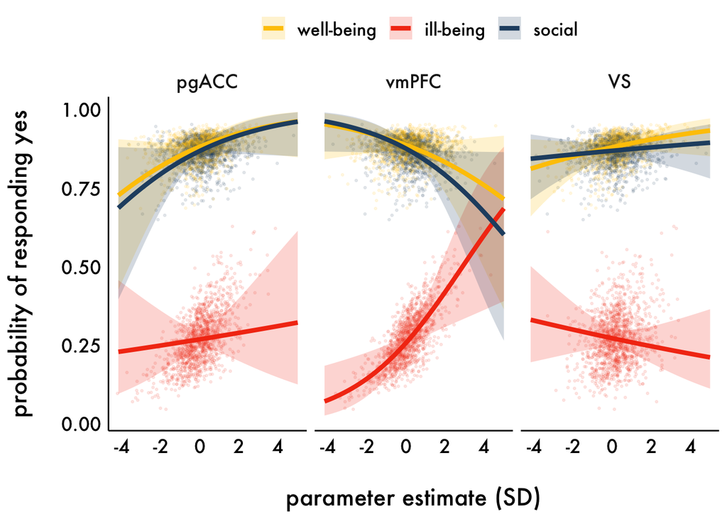

```r
raw_values = data_complete_mod %>%
  select(subjectID, construct, pgACC, vmPFC, VS)

raw_values$predicted_logit = predict(model_2, newdata = raw_values, re.form = as.formula("~(1 | subjectID)"))

raw_values = raw_values %>%
  gather(roi, x, pgACC, VS, vmPFC) %>%
  rename("group" = construct) %>%
  mutate(predicted = logit2prob(predicted_logit))

vals = seq(round(min(raw_values$x),1), round(max(raw_values$x), 1), .2)

predicted = ggeffect(model_2, terms = c("pgACC [vals]", "construct")) %>%
  data.frame() %>%
  mutate(roi = "pgACC") %>%
  bind_rows(ggeffect(model_2, terms = c("VS [vals]", "construct")) %>%
    data.frame() %>%
    mutate(roi = "VS")) %>%
  bind_rows(ggeffect(model_2, terms = c("vmPFC [vals]", "construct")) %>%
    data.frame() %>%
    mutate(roi = "vmPFC"))

predicted %>%
  ggplot(aes(x, predicted, fill = group)) +
  geom_point(data = raw_values, aes(color = group), alpha = .1, size = .5) +
  geom_ribbon(aes(ymin = conf.low, ymax = conf.high), alpha = .2) +
  geom_line(aes(color = group), size = 1.5) +
  facet_grid(~roi) +
  scale_color_manual(values = constructs, name = "") +
  scale_fill_manual(values = constructs, name = "") +
  scale_x_continuous(breaks = seq(-6, 6, 2)) +
  labs(x = "\nparameter estimate (SD)", y = "probability of responding yes\n") +
  plot_aes
```

### by ROI

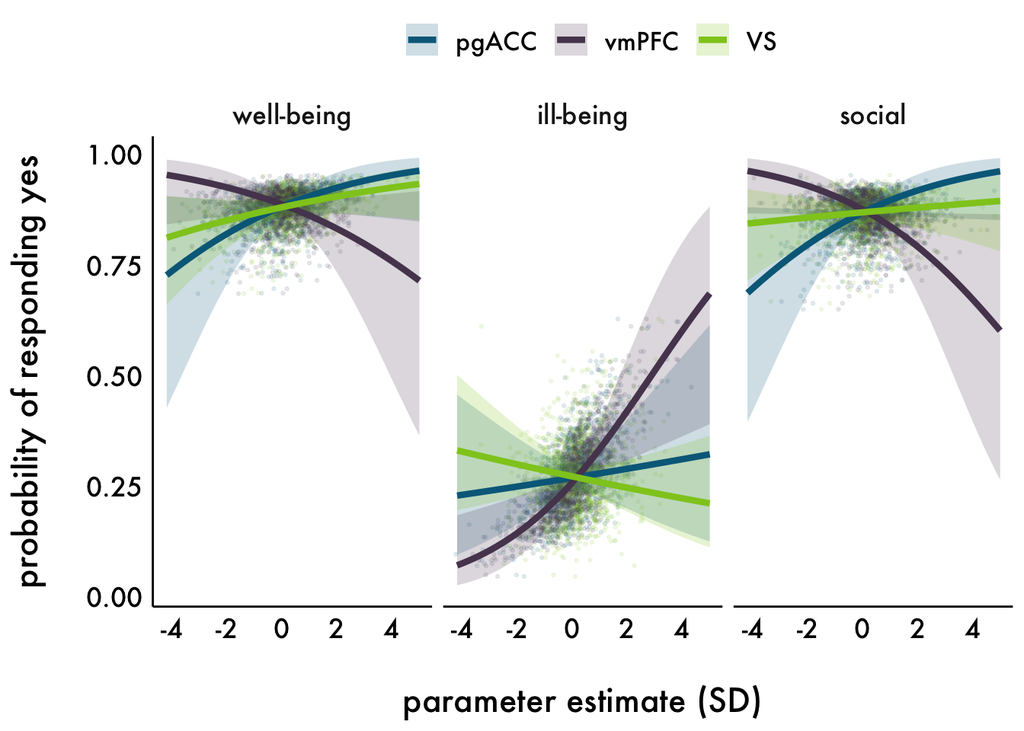

```r
predicted %>%
  ggplot(aes(x, predicted, fill = roi)) +
  geom_point(data = raw_values, aes(color = roi), alpha = .1, size = .5) +
  geom_ribbon(aes(ymin = conf.low, ymax = conf.high), alpha = .2) +
  geom_line(aes(color = roi), size = 1.5) +
  facet_grid(~group) +
  scale_color_manual(values = rois, name = "") +
  scale_fill_manual(values = rois, name = "") +
  scale_x_continuous(breaks = seq(-6, 6, 2)) +
  labs(x = "\nparameter estimate (SD)", y = "probability of responding yes\n") +
  plot_aes
```